# Testing feasibility - recruitment, adherence and data collection

D. T. Wilson

22 May, 2019

## Hypotheses

We first find the threshold values $x_0, x_1$ which correspond to obtaining 60 and 80% power and set our mean difference, $\mu$.

```r
mu <- 0.3
p0 <- 0.6; p1 <- 0.8

x0 <- (qnorm(p0) + qnorm(0.975))
x1 <- (qnorm(p1) + qnorm(0.975))
```

These in turn define our hypotheses, $\hat{\Phi}_0$ and $\hat{\Phi}_1$. We can visualise the boudaries of these spaces:

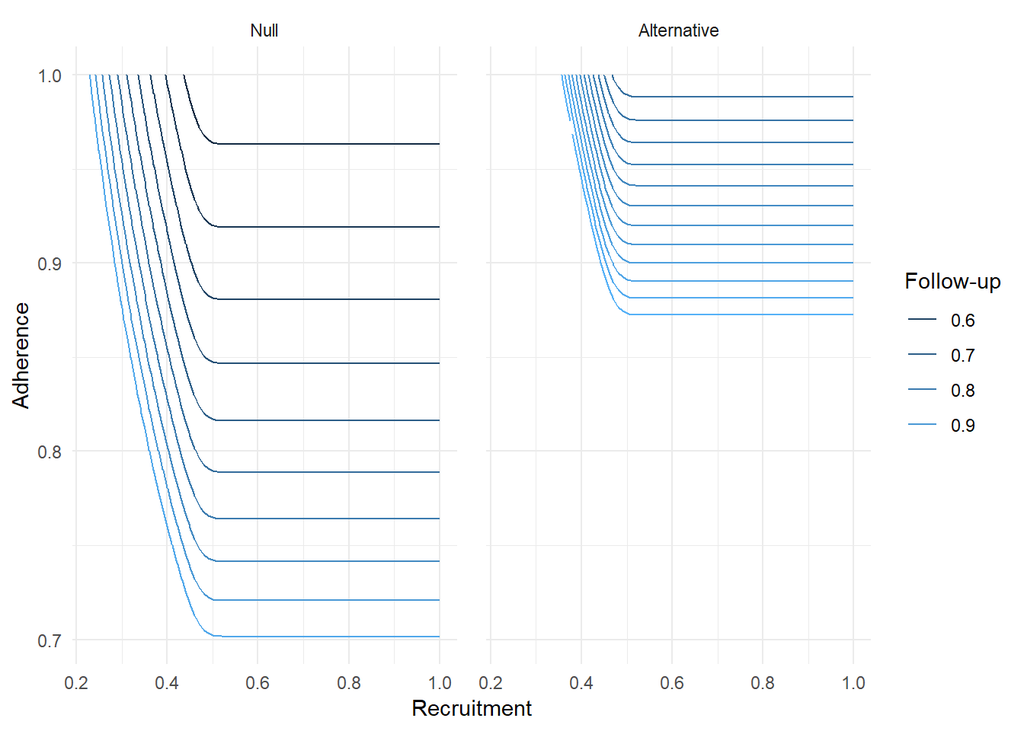

```r
get_exp_N <- function(n_e, n_t, phi_r)
{
  # Calculate the expected number recruited into the main trial
  n_r <- 0:(n_t-1)
  sum(dbinom(n_r, n_e, phi_r)*n_r) + n_t*(1-pbinom(n_t-1, n_e, phi_r))
}

get_fup <- function(phi, xi, mu, n_e, n_t)
{
  # For some recruitment and adherence rate, find the follow-up rate which will lie on
  # the boundary of the hypothesis defined by xi
  p_r <- phi[1]; p_a <- phi[2]; sd <- 1
  exp_n <- get_exp_N(n_e, n_t, p_r)
  (2*sd^2 + mu^2 *p_a*(1-p_a))*xi^2/((p_a*mu)^2*exp_n)

}

# Null
df <- expand.grid(p_r=seq(0,1,0.01), p_a=seq(0,1,0.01))
df$p_f <- apply(df, 1, get_fup, xi=x0, mu=mu, n_e = 500, n_t =235)
sub <- df

# Alternative
df <- expand.grid(p_r=seq(0,1,0.01), p_a=seq(0,1,0.01))
df$p_f <- apply(df, 1, get_fup, xi=x1, mu=mu, n_e = 500, n_t =235)
sub_a <- df

# Combine for plotting
sub$h <- "Null"
sub_a$h <- "Alternative"
sub <- rbind(sub, sub_a)
# Discard any infeasible points
sub <- sub[sub$p_f <= 1,]

ggplot(sub, aes(p_r, p_a, z=p_f, colour=p_f)) +
  geom_contour(aes(colour=..level..)) +
  theme_minimal() + xlab("Recruitment") + ylab("Adherence") +
  guides(colour = guide_legend(title = "Follow-up")) +
  facet_grid(. ~ factor(h, levels=c("Null", "Alternative"))) +
  theme(panel.spacing = unit(1, "lines"))
```

```r
ggsave("./paper/figures/hyps.pdf", height=9, width=14, units="cm")
ggsave("./paper/figures/hyps.eps", height=9, width=14, units="cm", device = cairo_ps())
```

## Local error rates

Having defined our hypotheses, we can now calculate local type I and II error rates for a proposed pilot trial with sample size $n$, critical value $c$, and at two specific points in the null and alternative hypotheses.

```r
# Using a c++ implemntation of forumla (X)
Rcpp::sourceCpp('./src/comp_ocs.cpp')

get_ocs <- function(y, n, x0, x1, mu=0.3, n_e, n_t)
{
  # Input y = (c, [point in null space], point in alternative space])
  c <- y[1]; sd <- 1

  # Probability of +ve result at the null point
  p_r <- y[2]; p_a <- y[3]; p_f <- y[4];
  alpha <- get_comp_ocs_cpp3(matrix(c(c, p_r, p_a, p_f, sd), ncol=5), n, mu, n_e, n_t)

  # Probability of -ve result at the alternative point
  p_r <- y[5]; p_a <- y[6]; p_f <- y[7];
  beta <- 1 - get_comp_ocs_cpp3(matrix(c(c, p_r, p_a, p_f, sd), ncol=5), n, mu, n_e, n_t)

  # Returning negative values for optimisation later
  return(-c(alpha, beta))
}

# For example,
get_ocs(c(2.4, 0.64, 0.73, 0.8769883, 0.96, 1, 0.7422108), 30, x0, x1, 0.3, 500, 235)
```

```
## [1] -0.2291256817 -0.0007978414
```

## Global error rate curves

To solve the multi-objective optimisation problem described in the paper, we need to implment a constriant function to limit the search to our null and alternative hypotheses. The function returns a value for the null (alternative) point, being negative if the point is not within the null (alternative) hypothesis.

```r
get_constr <- function(y, n, x0, x1, mu=0.3, n_e, n_t)
{
  sd <- 1

  p_r <- y[2]; p_a <- y[3]; p_f <- y[4];
  exp_n <- get_exp_N(n_e, n_t, p_r)
  con_a <-  p_a*mu*sqrt(p_f*exp_n)/sqrt(2*sd^2 + mu^2 * p_a*(1-p_a))

  p_r <- y[5]; p_a <- y[6]; p_f <- y[7];
  exp_n <- get_exp_N(n_e, n_t, p_r)
  con_b <-  p_a*mu*sqrt(p_f*exp_n)/sqrt(2*sd^2 + mu^2 * p_a*(1-p_a))

  return(c(x0-con_a, con_b-x1))
}

# For example, change the alternative point from above so it is outside the alternative hypothesis
get_constr(c(2.4, 0.64, 0.73, 0.8769883, 0.96, 0.9, 0.7422108), 30, x0, x1, 0.3, 500, 235)
```

```
## [1]  4.144798e-08 -2.852490e-01
```

We can now sole the problem using the NSGA-II algrothim from the “mco” package. Note that while there is an option to use a fully vectorised version (i.e. with the objective and constrained functions implemented in c++), this did not lead to any efficiency gain and so we have used R functions for greater transparancy.

```r
opt <- nsga2(fn=get_ocs, 7, 2,
             n=30, x0=x0, x1=x1, mu=0.3, n_e=500, n_t=234,
             lower.bounds = c(2, rep(0.1,6)), upper.bounds = c(3, rep(1,6)),
             generations = 1:100, popsize = 100,
             constraints = get_constr, cdim=2)

saveRDS(opt, "opt.Rda")
```

The algorithm returns a set of `popsize` solutions, each containing a critical value, a point in the null, and a point in the alternative. Each solution has a type I and II error, which we can plot to visualise the error rates available as we vary the critical value but keep the pilot sample size fixed.

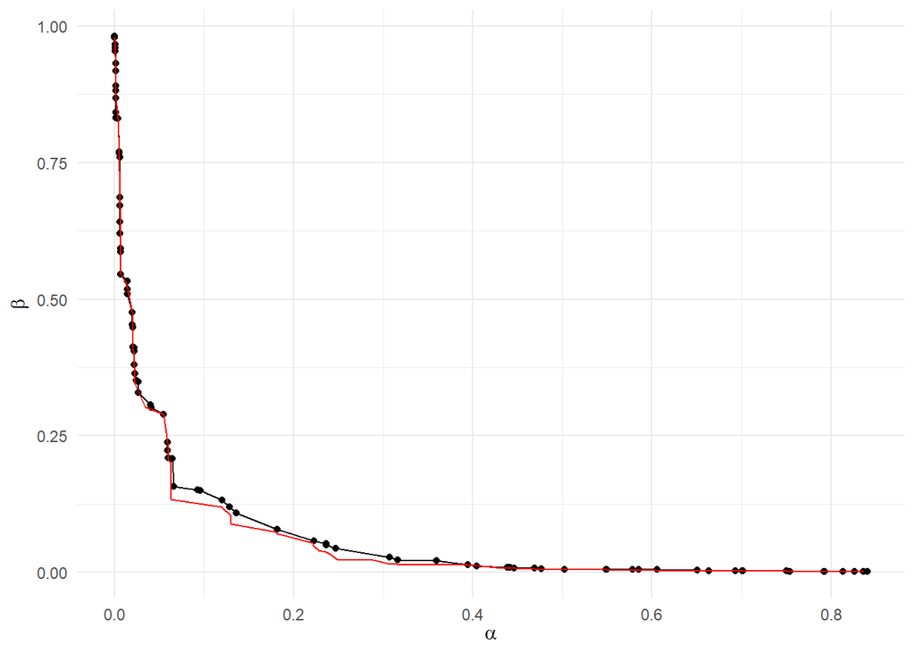

```r
opt <- readRDS("opt.Rda")

df <- data.frame(a=-opt[[100]]$value[,1], b=-opt[[100]]$value[,2])
df2 <- data.frame(a=-opt[[80]]$value[,1], b=-opt[[80]]$value[,2])

ggplot(df, aes(a, b)) + geom_point() + geom_line() +
  geom_line(data=df2, colour="red") +
  xlab(expression(alpha)) + ylab(expression(beta)) +
  theme_minimal()
```

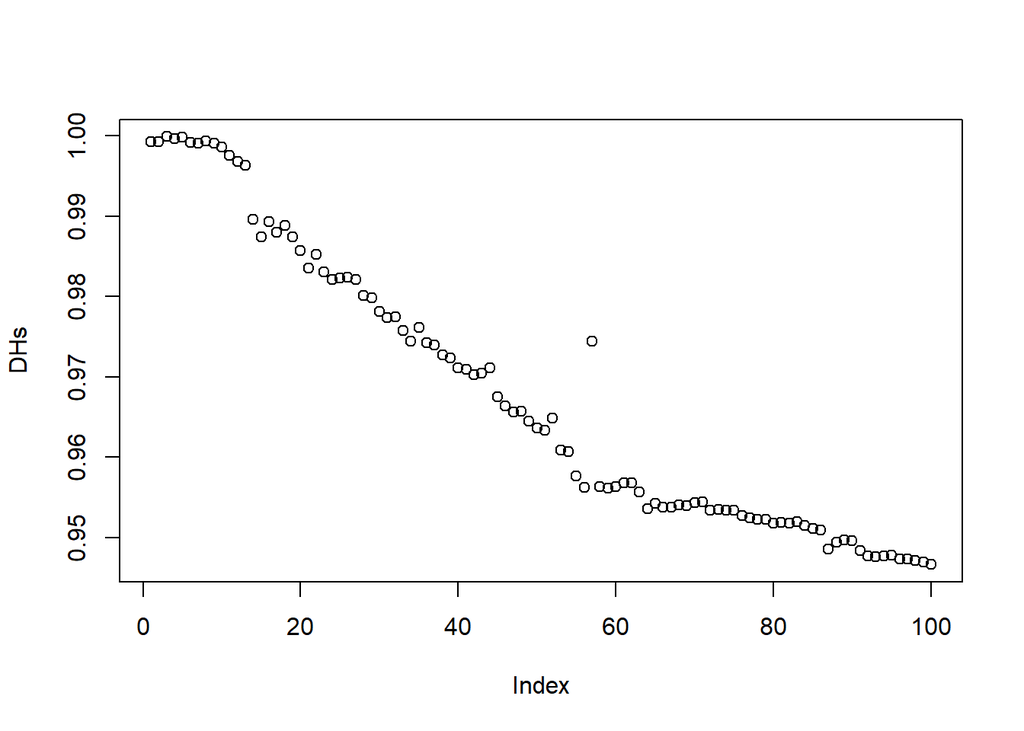

```r
DHs <- NULL
for(i in 1:length(opt)){
  dh <- dominatedHypervolume(-opt[[i]]$value, c(1,1))
  DHs <- c(DHs, dh)
}
plot(DHs)
```

## Comparison

We can comapre the error rate curve of the proposed method against that of the current approach, where the three parameter estimates are compared against seperate progression criteria thresholds and a “go” decision is made only if they are all exceeded.

```r
get_oc_pc <- function(phi, cs, n, xi, tI, s, f, a, n_e, n_t)
{
  p_r <- phi[1]; p_a <- phi[2]; sd <- 1
  if(any(c(p_r,p_a) < 0) | any(c(p_r,p_a) > 1) ){return(1000)}
  exp_n <- get_exp_N(n_e, n_t, p_r)
  p_f <- (2*sd^2 + mu^2 *p_a*(1-p_a))*xi^2/((p_a*mu)^2*exp_n)
  if(any(c(p_r,p_a,p_f) < 0) | any(c(p_r,p_a,p_f) > 1) ){
    1000
  } else {
    (tI*-1 + !tI*1)*pnbinom(s, 2*n, p_r)*(1- pbinom(f, 2*n, p_f))*(1 - pbinom(a, n, p_a))
  }
}

get_ocs_pc <- function(cs, n, x0, x1, n_e, n_t)
{
  # First, get the numbers corresponding to the
  # critical values and their respective probabilities

  # Recruitment
  s <- floor(2*n/cs[1] - 2*n)
  # Adherence
   a <- cs[2]*n
  # Follow-up
  f <- cs[3]*2*n

  # Locally optimise
  opt_a <- optim(c(0.9,0.9), fn=get_oc_pc,# lower = c(0.1,0.1), upper=c(1,1),
                 cs=cs, n=n, xi=x0, tI=T, s=s, f=f, a=a, n_e=n_e, n_t=n_t)#, method="L-BFGS-B")

  opt_b <- optim(c(0.9,0.9), fn=get_oc_pc,# lower = c(0.1,0.1), upper=c(1,1),
                 cs=cs, n=n, xi=x1, tI=F, s=s, f=f, a=a, n_e=n_e, n_t=n_t)#, method="L-BFGS-B")

  c(-opt_a$value, 1-opt_b$value)
}

# For example,
get_ocs_pc(rep(0.5, 3), 30, x0, x1, n_e=500, n_t=235)
```

```
## [1] 9.996379e-01 4.991331e-05
```

We can search over all possible progression criteria and plot the best available error rates. As a check that the optimisation algorithm is working well, we also evaluate a $10^4$ size space-filling design (specifically, a Sobol sequence) and plot the results.

```r
opt <- nsga2(get_ocs_pc, 3, 2, n=30, x0=x0, x1=x1, n_e=500, n_t=235,
             lower.bounds = c(0, 0, 0), upper.bounds = c(1, 1, 1),
              popsize = 100, generations = 100)
# saveRDS(opt, "./data/opt_pc.Rda")

to_eval <- sobol(10000,3)
ocs <- apply(to_eval, 1, get_ocs_pc, n=30, x0=x0, x1=x1, n_e=500, n_t=235)
# saveRDS(ocs, "./data/sobol_pc.Rda")
```

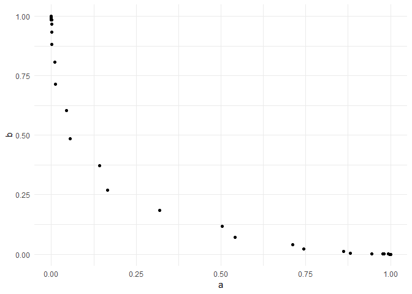

```r
# Optimisation
opt <- readRDS("./data/opt_pc.Rda")
opt_df <- as.data.frame(opt$value)

# Sobol sequence
ocs <- readRDS("./data/sobol_pc.Rda")
sob_df <- as.data.frame(t(ocs))

names(opt_df) <- names(sob_df) <- c("a", "b")
opt_df$t <- 1; sob_df$t <- 2
df <- rbind(opt_df, sob_df)

p <- ggplot(df, aes(a,b)) + geom_point() + theme_minimal() +
  transition_states(t)
animate(p, nframes = 2, fps=0.8)
```

## Evaluation

We find the OC curves produced by the proposed method and for the comparator for a range of null hypothesis power parameters and a range of total sample sizes of the main trial. FOr each scenario, we consider pilot sample sizes of n = 30, 50 and 100.

```r
eval_scenario <- function(null_pow, n_t, n)
{
  print(n)
  p0 <- null_pow; p1 <- 0.8

  x0 <- qnorm(p0) + qnorm(0.975)
  x1 <- qnorm(p1) + qnorm(0.975)

  opt <- nsga2(fn=get_ocs, 7, 2,
             n=n, x0=x0, x1=x1, mu=0.3, n_e=500, n_t=n_t,
             lower.bounds = c(2, rep(0.1,6)), upper.bounds = c(3, rep(1,6)),
             generations = 100, popsize = 100,
             constraints = get_constr, cdim=2)

  opt_comp <- nsga2(get_ocs_pc, 3, 2, n=n, x0=x0, x1=x1, n_e=500, n_t=n_t,
             lower.bounds = c(0, 0, 0), upper.bounds = c(1, 1, 1),
              popsize = 100, generations = 100)

  df <- data.frame(a=c(opt$value[,1], opt_comp$value[,1]),
                   b=c(opt$value[,2], opt_comp$value[,2]),
                   t=c(rep("FT", 100), rep("PC", 100)))
  df$n <- n; df$n_t <- n_t; df$null_pow <- null_pow

  return(df)
}

df <- NULL
for(i in c(234, 234*1.1, 234*1.2)){
  for(j in c(0.6, 0.65, 0.7)){
    for(k in c(30, 50, 100)){
          df <- rbind(df, eval_scenario(j, i, k))
    }
  }
}

#saveRDS(df, "./data/eval.Rda")
```

Plot the results

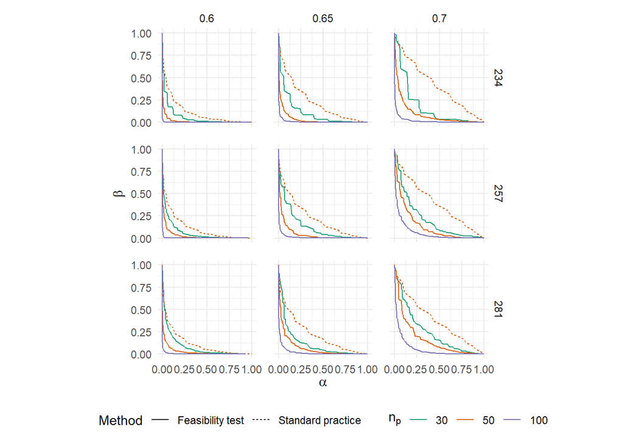

```r
df <- readRDS("./data/eval.Rda")
names(df)[4] <- "np"
df$a <- ifelse(df$t=="FT", -df$a, df$a)
df$b <- ifelse(df$t=="FT", -df$b, df$b)

labels_nt <- c("234" = "234", "257.4" = "257", "280.8" = "281")

ggplot(df[df$t == "FT" | df$np == 50,], aes(a, b, colour=as.factor(np), linetype=t)) + geom_line() +
  facet_grid(n_t ~ null_pow, labeller = labeller(n_t = labels_nt)) +
  theme_minimal() + coord_fixed() +
  xlab(expression(alpha)) + ylab(expression(beta)) +
  scale_color_manual(name=expression(n[p]), values=cols) +
  scale_linetype(name="Method", labels=c("Feasibility test", "Standard practice")) +
  theme(panel.spacing = unit(1, "lines"), legend.position="bottom") +
  scale_x_continuous(breaks=c(0, 0.25, 0.5, 0.75, 1))
```

```r
ggsave("./paper/figures/eval.pdf", height=16, width=18, units="cm")
ggsave("./paper/figures/eval.eps", height=16, width=18, units="cm", device = cairo_ps())
```

Pick out some specific numbers for comparison.

```r
df[df$n_t == 234 & df$a > 0.08 & df$a < 0.12 & df$t == "FT" & df$np == 30,]
```

```
##             a         b  t np n_t null_pow
## 14  0.1160367 0.1700569 FT 30 234     0.60
## 71  0.1187477 0.1519272 FT 30 234     0.60
## 78  0.1162266 0.1601183 FT 30 234     0.60
## 629 0.1063633 0.3244761 FT 30 234     0.65
## 633 0.1063633 0.3244761 FT 30 234     0.65
## 665 0.1196824 0.3231196 FT 30 234     0.65
```

Look at one example graph in more detail.

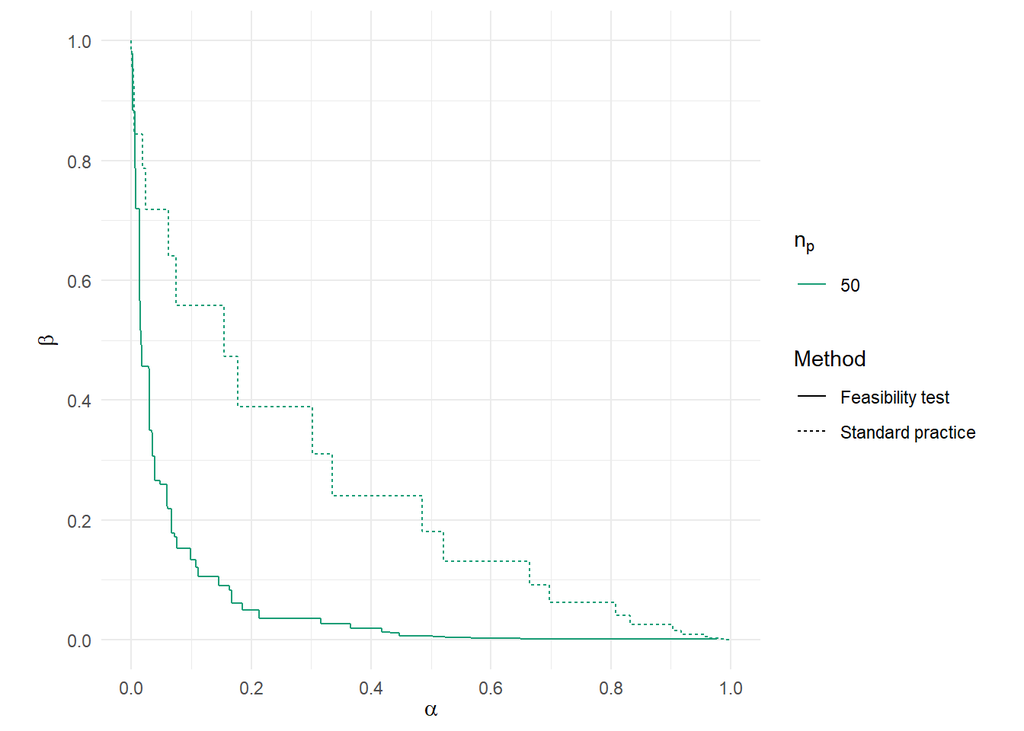

```r
sub <- df[df$null_pow == 0.65 & df$n_t == "257.4" & df$np == 50,]

ggplot(sub, aes(a,b,colour=as.factor(np), linetype=t)) + geom_step() + #geom_point() +
  theme_minimal() + coord_fixed() +
  xlab(expression(alpha)) + ylab(expression(beta)) +
  scale_color_manual(name=expression(n[p]), values=cols) +
  scale_linetype(name="Method", labels=c("Feasibility test", "Standard practice")) +
  scale_x_continuous(breaks=c(0, 0.2, 0.4, 0.6, 0.8, 1)) +
  scale_y_continuous(breaks=c(0, 0.2, 0.4, 0.6, 0.8, 1))
```

```r
ggsave("./paper/figures/ex_ocs.pdf", height=9, width=14, units="cm")
ggsave("./paper/figures/ex_ocs.eps", height=9, width=14, units="cm", device = cairo_ps())
```

## Extensions

### Correlated follow-up and adherence